# Table of Contents

This notebook is written by Zhengjie (Jay) Xu and tends to explain the theory behind Naive Bayes classifier step by step, in order to better understand the logic behind the [code](https://github.com/fastai/fastai/blob/master/courses/ml1/lesson5-nlp.ipynb). The code is part of the **Intro to Machine Learning Class** taught by Jeremy Howard at [fastai](http://www.fast.ai/).

# Bayes framework

## From conditional probability to Bayes theorem

Let $d$ denotes a document(movie review), and $c$ denotes the class lable of the document(positive or negative). According to `conditional probability`:

$p(c|d) = \frac{p(cd)}{p(d)}$ (1)  
$p(d|c) = \frac{p(cd)}{p(c)}$ (2)

where

- $p(c|d)$ is the conditional probability of class label giving a document
- $p(d|c)$ is the conditional probability of a document giving a class label
- $p(c)$ is the frequency(ratio) of each class label in the training set
- $p(d)$ is the frequency(ratio) of each document in the training set
- $p(cd)$ is the joint probability of class label and document

Replacing $p(cd)$ in equation (1) with equation (2), we get `Bayes formula`:

$p(c|d) = \frac{p(c)\cdot p(d|c)}{p(d)}$ (3)

where

- We call $p(c)$ `prior probability`, which represents our prior knowledge about the distribution(probability) of class labels
- We call $p(c|d)$ the `posterior probability` of class labels. which is what we want to calculate
- We call $p(d|c)$ `likelihood` and $p(d)$ `evidence`, which are used to update `prior probaility` to `posterior probability` of class labels

## Bag of words

We represent each document $d$ using the bag of word framework. Let $\left\{f_1,f_2,...,f_m\right\}$ be a set of $m$ words that can appear in all documents; $f_i$ can be unigram like 'great' or bigram like 'really stinks'.

Let $n_i$ be the number of times $f_i$ occurs in document $d$. Then each document $d$ is represented by the document vector:

$\vec{d}=(n_1, n_2,...,n_m)$ (4)

Thus, $p(d|c)$ can be represented as the set of words $f_i$:

$p(d|c) = p(f_1,f_2,...,f_m|c)$ (5)

which means given a specific class label, the joint probability to have specific words.

## What does it mean to be naive?

The `Naive` means that we assume each word is independent of the other, thus their joint probability can be expanded to the product of individual probability. Equation (5) becomes:

$p(d|c) = p(f_1,f_2,...,f_m|c) = p(f_1|c)^{n_1}\cdot p(f_2|c)^{n_2} \cdot ... \cdot p(f_m|c)^{n_m}$ (6)

where each $p(f_i|c)^{n_i}$ is the conditional probability of $word_i$ that occurs $n_i$ times, giving a class label. And it measures the contribution of each word to the prediction of class label.  
Put equation (3) and (6) together, the `posterior probability` $p(c|d)$ can be expressed as:

$p(c|d) = \frac{p(c) \cdot p(f_1|c)^{n_1} \cdot p(f_2|c)^{n_2} \cdot ... \cdot p(f_m|c)^{n_m}}{p(d)}$ (7)

The numerator of equation (7) can be illustrated as following:

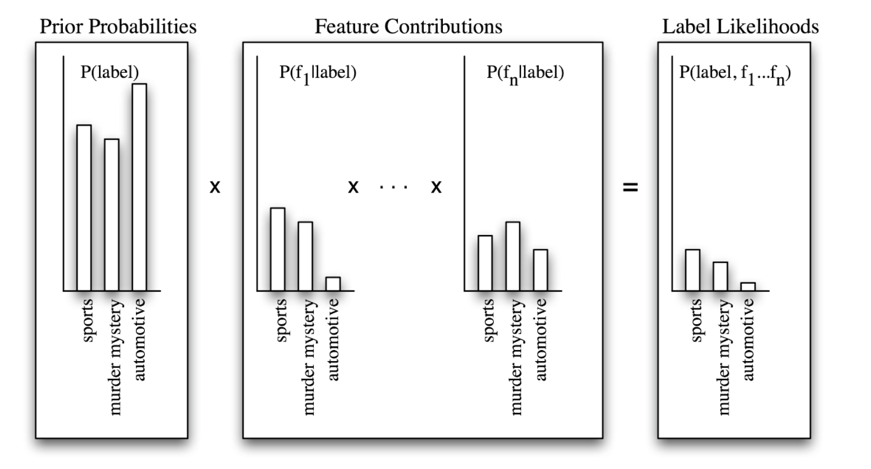

```python
from IPython.display import Image
src='image/Picture1.png'
Image(src, width=600, height=600)
```

Note that in practice, **the assumption of independence rarely holds**. However, the Naive Bayes still has a decent prediction accuracy.

## Use ratio for binary classifier

Recall that our goal is to classify a document(movie review). That is, given a document, choose the class label that maximizes the posterior probability $p(c|d)$.

Since our movie review only has positive and negative class, it is a binary classification problem. Assume positive class corresponds to $c=1$, and negtive class corresponds to $c=0$.  
For $c=1$, using equation (3):

$p(c=1|d) = \frac{p(c=1) \cdot p(d|c=1)}{p(d)}$ (8)

For $c=0$, using equation (3):

$p(c=0|d) = \frac{p(c=0) \cdot p(d|c=0)}{p(d)}$ (9)

Since when we are deciding whether a specific document is positive or negative, we are looking at the same document $d$. Thus the denominator $p(d)$ in the above two equation is the same thing. We can take the ratio of the two equation and cancel out the denominator:

$\frac{p(c=1|d)}{p(c=0|d)} = \frac{p(c=1)\cdot{p(d|c=1)}}{p(c=0)\cdot{p(d|c=0)}}$ (10)

Substitute $p(d|c)$ with equation (6):

$\frac{p(c=1|d)}{p(c=0|d)} = \frac{p(c=1)\cdot{p(f_1|c=1)^{n_1}}\cdot{p(f_2|c=1)^{n_2}}\cdot{...}\cdot{p(f_m|c=1)^{n_m}}}{p(c=0)\cdot{p(f_1|c=0)^{n_1}}\cdot{p(f_2|c=0)^{n_2}}\cdot{...}\cdot{p(f_m|c=0)^{n_m}}}$ (11)

If this ratio is larger than 1, then we can classify it as class 1; otherwise class 0.

## Algorithm

step1. Training:

- Use training corpus to calculate `prior probability` $p(c)$ and `likelihood` $p(f_i|c)$ for both $c=1$ and $c=0$.

step2. Predicting:

- Represent the new document using bag of words $(n_1, n_2,..., n_m)$, and then substitute $n_i$ in equation (11) and get the ratio
- If the ratio is larger than 1, then positive; otherwise negtive

## Simple example

### Example context

This example is part of my presentation of *Basic Sentiment Classifier* [here](https://github.com/zhengjxu/fastaiML/blob/master/Basic%20Sentiment%20Classifier_Zhengjie%20Xu.pdf).

Let's say we have a corpus of movie reviews used to train our model. Among the movie review, 50% of them are positive, and the remaining 50% are negative.

We have counted the frequency of each word in all training documents, the result is in the following table:

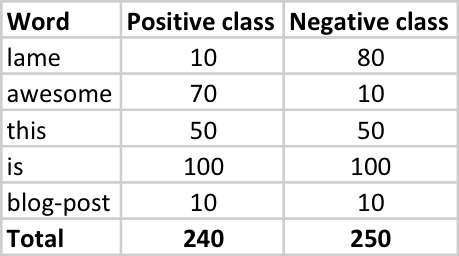

```python
from IPython.display import Image
src = 'image/Example_table.png'
Image(src, width=400, height=400)
```

Now we get a **test document**:

```
"This blog-post is awesome"
```

And we want to know whether this document is positive or negtive.

### Recall the meaning of each component in the formula

- $p(c)$: frequency of each class; prior probability; calculated by:

  $p(c_i)=\frac{document(c=c_i)}{N_{doc}}$
- $p(c|d)$: the conditional probability of class label given a document d. ; posterior probability
- $p(f_i|c=1)$: frequency of $word_i$ giving positive class, which is calculated by the number of $word_i$ in all positive documents/ the number of all words in all positive documents:

  $p(f_i|c=1)=\frac{count(f_i,c_{pos})}{\sum_{f\in V}count(f,c_{pos})}$
- $p(f_i|c=0)$: frequency of $word_i$ giving negative class, which is calculated by the number of $word_i$ in all negative documents/ the number of all words in all negative documents.

  $p(f_i|c=0)=\frac{count(f_i,c_{neg})}{\sum_{f\in V}count(f,c_{neg})}$

Note that for simplication, we do not apply [add-1 smoothing](https://stats.stackexchange.com/questions/272826/laplace-smoothing-and-naive-bayes) in our example.

### Caculation

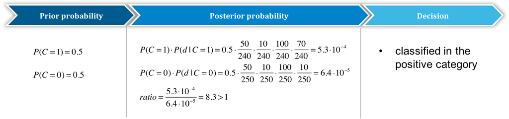

```python
from IPython.display import Image
src = 'image/calculation.png'
Image(src, width=800, height=1000)
```

## Use log ratio

The advantage of taking the log is to convert product into addition, then we can use matrix multiplication to simpliy calculation.

Take log on the two side of equation (11):

$log\frac{p(c=1|d)}{p(c=0|d)} = log\frac{p(c=1)}{p(c=0)}+n_1\cdot log\frac{p(f_1|c=1)}{p(f_1|c=0)}+n_2\cdot log\frac{p(f_2|c=1)}{p(f_2|c=0)}+...+n_m\cdot log\frac{p(f_m|c=1)}{p(f_m|c=0)}$ (12)

If log ratio > 0, then ratio > 1, we classify it as class 1.

If we set $b=log\frac{p(c=1)}{p(c=0)}$  
$\overrightarrow{r}=[log\frac{p(f_1|c=1)}{p(f_1|c=0)}, log\frac{p(f_2|c=1)}{p(f_2|c=0)}...log\frac{p(f_m|c=1)}{p(f_m|c=0)}]$  
$\overrightarrow{d}=[n_1, n_2,...,n_m]$  
Then we can express equation (12) using a matrix form:

$z=b+\overrightarrow{d}\cdot \overrightarrow{r}^{T}$ (13)

If z > 0, then positive; otherwise negative. **The code we learnt in lesson 5 is just based on equation (13)**

# Connection with neural net

Compared with a typical one-layer neural net, we have input layer $\overrightarrow{d}$, weight $\overrightarrow{r}$ and bias $b$. The difference is that, in a typical one-layer neural net, we use gradient descent to iteratively calculate weight. However, in Naive Bayes, the weight is calcualte based on Bayesian theorem.

The layer of a shallow neural net is like the following, with Gradien Descent to update the weights.

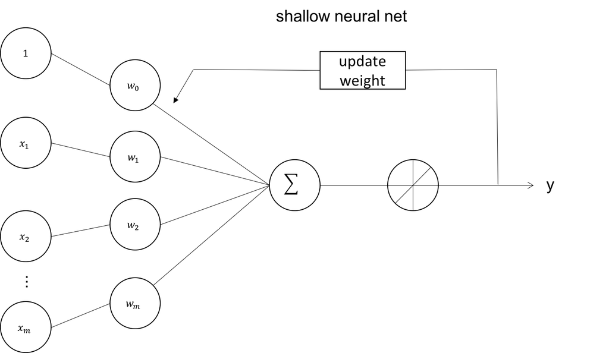

```python
from IPython.display import Image
src = 'image/shallow_NN.png'
Image(src, width=600, height=700)
```

The layer of Naive Bayes is like the following, with weight predefined by Bayes Theorom.

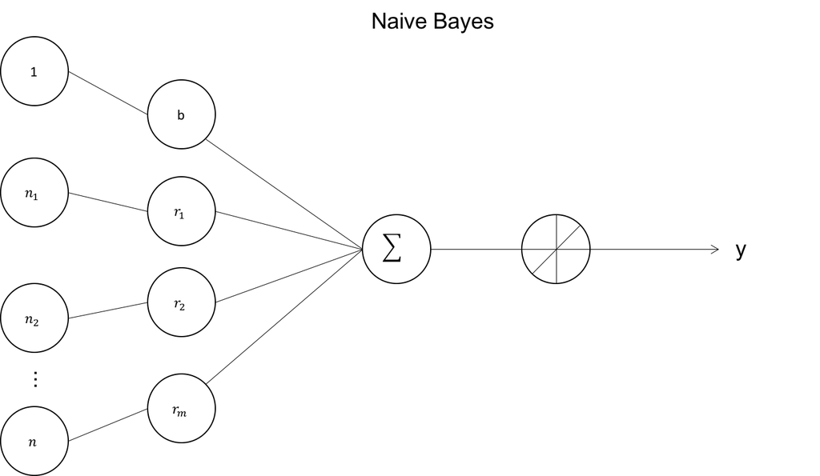

```python
from IPython.display import Image
src = 'image/NB_layer.png'
Image(src, width=600, height=700)
```